# load w2v into DocSim

```python
cd ..
```

```
C:\Users\miumermaid\Documents\JupyterNotebookFolder\Summerization
```

Abstract:  
Generating high quality summary that are succinct, syntactic correct, and accurate is an on-going challenge. Previously, there have been attempts to solve the repetition issue of Recursive Neural Network with attention and coverage. However, maintaining the original focus remains a challenge.  
Given plenty of redundant news, it can be inferred that known similar source documents should also produce similar abstracts. If the semantic meaning is always reduced by the same magnitude from source to summary under the same summarization model, then I propose to use these similarity relationships to predict summaries that deviate from their parents.  
Secondly, we could deploy an ensemble of summarization models; the summary most “neutral” in semantic and agreed upon by most models is most likely to be true. The final app would be a lightweight TensorFire model deployed to user’s device, allowing private and fast summarization.

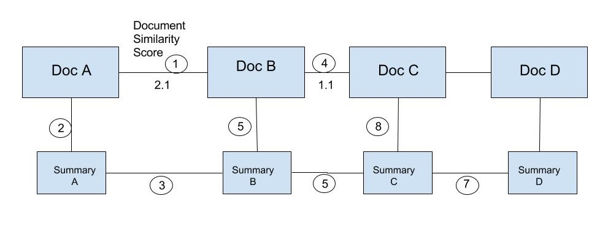

```python
from IPython.core.display import Image, display
display(Image('Summary.jpg', width=1900,height=1900, unconfined=False))
```

Executing the line "KeyedVectors.load_word2vec_format" can be quite memory intensive. Alternatively, we could take the first 50000 frequent word vectors instead, with "load_word2vec_format(model_path, binary=True, limit = 50000)"

```python
from gensim.models.keyedvectors import KeyedVectors
model_path = 'Google-pretrained-vectors/GoogleNews-vectors-negative300.bin'
w2v_model = KeyedVectors.load_word2vec_format(model_path, binary=True)
```

```python
#https://github.com/v1shwa/document-similarity
from DocSim import DocSim
ds = DocSim(w2v_model)
```

```python
source_doc = 'how to delete an invoice'
target_docs = ['delete a invoice', 'how do i remove an invoice', 'purge an invoice']

# This will return 3 target docs with similarity score
sim_scores = ds.calculate_similarity(source_doc, target_docs)

print(sim_scores)
```

```
[{'score': 0.87191433, 'doc': 'delete a invoice'}, {'score': 0.83031261, 'doc': 'how do i remove an invoice'}, {'score': 0.73876649, 'doc': 'purge an invoice'}]
```

In the following, sample summary outputs were taken from http://www.abigailsee.com/2017/04/16/taming-rnns-for-better-summarization.html . The summaries are in the order of Reference, Sequence-to-sequence + attention, Pointer-generator, and Pointer-generator model + coverage.

```python
sourceText = """munster have signed new zealand international francis saili on a two-year deal . \
utility back saili , who made his all blacks debut against argentina in 2013 , \
will move to the province later this year after the completion of his 2015 contractual commitments .\
the 24-year-old currently plays for auckland-based super rugby side the blues and was part of
the new zealand under-20 side that won the junior world championship in italy in 2011 . \
saili 's signature is something of a coup for munster and head coach anthony foley believes \
he will be a great addition to their backline . francis saili has signed a two-year deal to \
join munster and will link up with them later this year . ' we are really pleased that francis \
has committed his future to the province , ' foley told munster 's official website . ' \
he is a talented centre with an impressive skill-set and he possesses the physical attributes to \
excel in the northern hemisphere . ' i believe he will be a great addition to our backline and \
we look forward to welcoming him to munster . ' saili has been capped twice by new zealand and \
was part of the under 20 side that won the junior championship in 2011 . saili , who joins all \
black team-mates dan carter , ma'a nonu , conrad smith and charles piutau in agreeing to ply his trade in the northern hemisphere , is looking forward to a fresh challenge . he said : ' i believe this is a fantastic opportunity for me and i am fortunate to move to a club held in such high regard , with values and traditions i can relate to from my time here in the blues . ' this experience will stand to me as a player and i believe i can continue to improve and grow within the munster set-up . ' as difficult as it is to leave the blues i look forward to the exciting challenge ahead . '
"""
summary_docs = [
    #Reference summary
    'utility back francis saili will join up with munster later this year.\
the new zealand international has signed a two-year contract.\
saili made his debut for the all blacks against argentina in 2013.',
    #Sequence-to-sequence + attention summary
    'dutch international francis [UNK] has signed a two-year deal to join irish [UNK] \
    super rugby side the blues . [UNK] \'s signature is something of a coup for munster \
    and his head coach anthony foley believes he will be a great addition to \
    their respective prospects . [UNK] has been capped twice by new zealand .',
    #Pointer-generator summary
    'new zealand international francis saili will move to the province later this year .\
utility back saili made his all blacks debut against argentina in 2013 .\
utility back saili will move to the province later this year .',
    #Pointer-generator model + coverage summary
    'francis saili has signed a two-year deal to join munster later this year .\
the 24-year-old was part of the new zealand under-20 side that won the junior world championship \
in italy in 2011 . saili\'s signature is something of a coup for munster and head coach anthony foley .']

# This will return 3 target docs with similarity score
source_summary_similarity = ds.calculate_similarity(sourceText, summary_docs)
#print(source_summary_similarity)
```

Similarity score between the source text to each of its summary

```python
print([summary['score'] for summary in source_summary_similarity])
```

```
[0.89406443, 0.89123178, 0.86357182, 0.85789293]
```

```
    Part One: Find Cohort of similar documents to eliminate the summary that deviates
```

```python
#Similarity between Reference and Sequence-to-sequence + attention summary
summary_0_1_sim = ds.calculate_similarity(summary_docs[0],summary_docs[1])
print(summary_0_1_sim[0]['score'])
```

```
0.840378
```

```python
#Similarity between Sequence-to-sequence + attention summary and Pointer-generator
summary_1_2_sim = ds.calculate_similarity(summary_docs[1],summary_docs[2])
print(summary_1_2_sim[0]['score'])
print(summary_1_2_sim[0]['doc'])
```

```
0.771121
new zealand international francis saili will move to the province later this year .utility back saili made his all blacks debut against argentina in 2013 .utility back saili will move to the province later this year .
```

```python
#Similarity between Pointer-generator and Pointer-generator with coverage
summary_2_3_sim = ds.calculate_similarity(summary_docs[2],summary_docs[3])
print(summary_2_3_sim[0]['score'])
print(summary_2_3_sim[0]['doc'])
```

```
0.796756
francis saili has signed a two-year deal to join munster later this year .the 24-year-old was part of the new zealand under-20 side that won the junior world championship in italy in 2011 . saili's signature is something of a coup for munster and head coach anthony foley .
```

```python
#Similarity between Reference and Pointer-generator summary
summary_0_2_sim = ds.calculate_similarity(summary_docs[0],summary_docs[2])
print(summary_0_2_sim[0]['score'])
print(summary_0_2_sim[0]['doc'])
```

```
0.886593
new zealand international francis saili will move to the province later this year .utility back saili made his all blacks debut against argentina in 2013 .utility back saili will move to the province later this year .
```

```python
#Similarity between Reference and Pointer-generator with Coverage summary
summary_0_3_sim = ds.calculate_similarity(summary_docs[0],summary_docs[3])
print(summary_0_3_sim[0]['score'])
print(summary_0_3_sim[0]['doc'])
```

```
0.832664
francis saili has signed a two-year deal to join munster later this year .the 24-year-old was part of the new zealand under-20 side that won the junior world championship in italy in 2011 . saili's signature is something of a coup for munster and head coach anthony foley .
```

For a more sophisicated version, I'll also add filtering for unseen words that are not in the model's vocabulary set. Alternatively, we could leverage fastText's method to break the unknown word into smaller character n-grams and then assemble the word vector from vectors of these ngrams. However, another experiement shows that word2vec performs slightly better in terms of semantic similarities whereas fastText performs better on syntactic relations. https://rare-technologies.com/fasttext-and-gensim-word-embeddings/ So the optimal choice of word embeddings will depend on the nature of your text data.

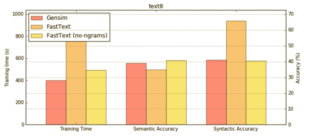

```python
from IPython.core.display import Image, display
display(Image('gensimW2V_vs_fastText.PNG', width=1900,height=1900, unconfined=False))
```

Known cluster of similar documents from Phan et al. for their work Learning to classify short and sparse text & web with hidden topics from large-scale data collections. https://dl.acm.org/citation.cfm?id=1367510 http://acube.di.unipi.it/repo/news.gz

###### ########### Please skip the next 10 cells of R&D code and continue to the next block

Below code taken from https://www.kernix.com/blog/similarity-measure-of-textual-documents_p12

```python
from sklearn.datasets import fetch_20newsgroups

from nltk import word_tokenize
from nltk import download
from nltk.corpus import stopwords

download('punkt')
download('stopwords')

stop_words = stopwords.words('english')

def preprocess(text):
    text = text.lower()
    doc = word_tokenize(text)
    doc = [word for word in doc if word not in stop_words]
    doc = [word for word in doc if word.isalpha()]
    return doc

# Fetch ng20 dataset
ng20 = fetch_20newsgroups(subset='train',
                          remove=('headers', 'footers', 'quotes'))

# text and ground truth labels
texts, y = ng20.data, ng20.target

corpus = [preprocess(text) for text in texts]
```

```
Downloading dataset from http://people.csail.mit.edu/jrennie/20Newsgroups/20news-bydate.tar.gz (14 MB)
```

```python
def filter_docs(corpus, texts, labels, condition_on_doc):
    """
    Filter corpus, texts and labels given the function condition_on_doc which takes
    a doc.
    The document doc is kept if condition_on_doc(doc) is true.
    """
    number_of_docs = len(corpus)

    if texts is not None:
        texts = [text for (text, doc) in zip(texts, corpus)
                 if condition_on_doc(doc)]

    labels = [i for (i, doc) in zip(labels, corpus) if condition_on_doc(doc)]
    corpus = [doc for doc in corpus if condition_on_doc(doc)]

    print("{} docs removed".format(number_of_docs - len(corpus)))

    return (corpus, texts, labels)

corpus, texts, y = filter_docs(corpus, texts, y, lambda doc: (len(doc) != 0))
```

```
320 docs removed
```

```python
import numpy as np
from gensim import corpora
from gensim.models import TfidfModel
from gensim.models import LsiModel
from gensim.similarities import MatrixSimilarity

sims = {'ng20': {}, 'snippets': {}}
dictionary = corpora.Dictionary(corpus)
corpus_gensim = [dictionary.doc2bow(doc) for doc in corpus]
tfidf = TfidfModel(corpus_gensim)
corpus_tfidf = tfidf[corpus_gensim]
lsi = LsiModel(corpus_tfidf, id2word=dictionary, num_topics=200)
lsi_index = MatrixSimilarity(lsi[corpus_tfidf])
sims['ng20']['LSI'] = np.array([lsi_index[lsi[corpus_tfidf[i]]]
                                for i in range(len(corpus))])
```

```python
def document_vector(word2vec_model, doc):
    # remove out-of-vocabulary words
    doc = [word for word in doc if word in word2vec_model.vocab]
    return np.mean(word2vec_model[doc], axis=0)
```

```python
def has_vector_representation(word2vec_model, doc):
    """check if at least one word of the document is in the
    word2vec dictionary"""
    return not all(word not in word2vec_model.vocab for word in doc)

corpus, texts, y = filter_docs(corpus, texts, y,
                               lambda doc: has_vector_representation(w2v_model, doc))

#snippets, _, snippets_labels = filter_docs(snippets, None, snippets_labels,
#                                           lambda doc: has_vector_representation(word2vec_model, doc))
```

```
3 docs removed
```

from sklearn.metrics.pairwise import cosine_similarity

sims['ng20']['centroid'] = cosine_similarity(np.array([document_vector(w2v_model, doc) for doc in corpus]))

```python
def most_similar(i, X_sims, topn=None):
    """return the indices of the topn most similar documents with document i
    given the similarity matrix X_sims"""

    r = np.argsort(X_sims[i])[::-1]
    if r is None:
        return r
    else:
        return r[:topn]

#LSI
print(most_similar(0, sims['ng20']['LSI'], 20))
#print(most_similar(0, sims['snippets']['LSI'], 20))

#Centroid
print(most_similar(0, sims['ng20']['centroid'], 20))
#print(most_similar(0, sims['snippets']['centroid'], 20))
```

```
[    0  5389  9743  8122  8308  1184  8028  6392  7580  7764  7782  9918
  8202  3697  6436  1051  8759  6146 10761  8289]
[    0  2472  3013  3697  7633  5123 10905  9826  9184  6851  3316 10961
  1079  6231  9313  1561  8160  2210  5148  6028]
```

###### ##### End of ignore block

We use a set of summaries from CNN articles made available by:  
Hermann, K. M., Kocisky, T., Grefenstette, E., Espeholt, L., Kay, W., Suleyman, M., & Blunsom, P. (2015). Teaching machines to read and comprehend. In Advances in Neural Information Processing Systems (pp. 1684-1692).  
https://cs.nyu.edu/~kcho/DMQA/

```python
#m.infer_vector(d, alpha=start_alpha, steps=infer_epoch)
```

Rouge: Lin, C. Y. (2004, July). Rouge: A package for automatic evaluation of summaries. In Text summarization branches out: Proceedings of the ACL-04 workshop (Vol. 8). http://www.aclweb.org/anthology/W04-1013  
BLEU: Papineni, K., Roukos, S., Ward, T., & Zhu, W. J. (2002, July). BLEU: a method for automatic evaluation of machine translation. In Proceedings of the 40th annual meeting on association for computational linguistics (pp. 311-318). Association for Computational Linguistics. http://anthology.aclweb.org/W/W04/W04-1013.pdf